# Peer Assignment 2

Isaac Moore

April 5, 2016

## Synopsis

This data analysis will use data from the U.S. National Oceanic and Atmospheric Administration’s (NOAA) stop database. The data that will be used is from 1950 (when the NOAA database was established) to November 2011. This analysis will attempt to determine which storm events are most harmful, in terms of fatalities and injuries and which storm events cause the greatest economic consequences.

### Data Processing

Loading libraries to be used

```r
library(dplyr)
```

```r
library(ggplot2)
```

Set the working directory for the analysis

```r
wd <- setwd("~/Google Drive/Data Science/Coursera - John Hopkins University/Course 5 - Reproducible Research/Week 4/Peer Assignment 2")
```

Download the data to the working directory

```r
fileURL <- "https://d396qusza40orc.cloudfront.net/repdata%2Fdata%2FStormData.csv.bz2"
download.file(fileURL, destfile = paste0(wd, "/stormdata.csv.bz2"), method = "curl")
```

Add the data to the environment and view the data

```r
data <- tbl_df(read.csv("stormdata.csv.bz2", header = TRUE, sep = ",", stringsAsFactors = FALSE))
data
```

```
## Source: local data frame [902,297 x 37]
##
##    STATE__           BGN_DATE BGN_TIME TIME_ZONE COUNTY COUNTYNAME STATE
##      (dbl)              (chr)    (chr)     (chr)  (dbl)      (chr) (chr)
## 1        1  4/18/1950 0:00:00     0130       CST     97     MOBILE    AL
## 2        1  4/18/1950 0:00:00     0145       CST      3    BALDWIN    AL
## 3        1  2/20/1951 0:00:00     1600       CST     57    FAYETTE    AL
## 4        1   6/8/1951 0:00:00     0900       CST     89    MADISON    AL
## 5        1 11/15/1951 0:00:00     1500       CST     43    CULLMAN    AL
## 6        1 11/15/1951 0:00:00     2000       CST     77 LAUDERDALE    AL
## 7        1 11/16/1951 0:00:00     0100       CST      9     BLOUNT    AL
## 8        1  1/22/1952 0:00:00     0900       CST    123 TALLAPOOSA    AL
## 9        1  2/13/1952 0:00:00     2000       CST    125 TUSCALOOSA    AL
## 10       1  2/13/1952 0:00:00     2000       CST     57    FAYETTE    AL
## ..     ...                ...      ...       ...    ...        ...   ...
## Variables not shown: EVTYPE (chr), BGN_RANGE (dbl), BGN_AZI (chr),
##   BGN_LOCATI (chr), END_DATE (chr), END_TIME (chr), COUNTY_END (dbl),
##   COUNTYENDN (lgl), END_RANGE (dbl), END_AZI (chr), END_LOCATI (chr),
##   LENGTH (dbl), WIDTH (dbl), F (int), MAG (dbl), FATALITIES (dbl),
##   INJURIES (dbl), PROPDMG (dbl), PROPDMGEXP (chr), CROPDMG (dbl),
##   CROPDMGEXP (chr), WFO (chr), STATEOFFIC (chr), ZONENAMES (chr), LATITUDE
##   (dbl), LONGITUDE (dbl), LATITUDE_E (dbl), LONGITUDE_ (dbl), REMARKS
##   (chr), REFNUM (dbl)
```

### Conversion

The class of the “BGN_DATE” observations are characters. I will convert the date variables to DATE class.

```r
data$BGN_DATE <- as.Date(data$BGN_DATE, "%m/%d/%Y")
class(data$BGN_DATE)
```

```
## [1] "Date"
```

We can see from this [codebook](https://rstudio-pubs-static.s3.amazonaws.com/58957_37b6723ee52b455990e149edde45e5b6.html) that the measurement for property damage and crop damage are in seperate fields, one displaying the dollar amount and the other field displaying the factor - Thousand (“K” or “k”), Millions (“M” or “m”), or Billions(“B”, “b”), and Numbers displaying displaying Tens, which will not need to be converted.  
Displaying the seperation.

```r
table(data$PROPDMG)
```

```
##
##      0   0.01   0.02   0.03   0.04   0.05   0.06   0.07   0.08    0.1
## 663123    931     80   1610      4    588     25      4      2   1513
##   0.11   0.12   0.13   0.15   0.16   0.17   0.18    0.2   0.21   0.22
##     27      7      1     46      3      3      1    568      2      1
##   0.23   0.25   0.26    0.3   0.33   0.34   0.35   0.36    0.4   0.41
##      1   1978      1    284      4      2      7      1    110      1
##   0.45    0.5   0.51   0.55    0.6   0.63   0.65   0.66    0.7   0.74
##      3   6790      2      2    101      3      5      1    107      1
##   0.75   0.76   0.78    0.8   0.81   0.84   0.85   0.86   0.87    0.9
##    471     11      1    136      1      1     14      2      1    360
##   0.95   0.99      1   1.01   1.02   1.03   1.04   1.05   1.06   1.07
##      1      2  19069      4      5      2      6     11      4      3
##   1.08    1.1   1.11   1.13   1.14   1.15   1.16   1.17   1.18   1.19
##      1     88      4      6      2     16      2      2      1      1
```

[output cut: 264 more lines]

```r
table(data$CROPDMG)
```

```
##
##      0   0.01   0.02   0.03   0.05    0.1   0.15    0.2   0.24   0.25
## 880198      7      3      1    163     18      3     35      1      3
##   0.28    0.3    0.4    0.5    0.6    0.7   0.75    0.8    0.9      1
##      1     10      6    575      5      4     15     12      4   1404
##   1.05    1.1   1.12    1.2   1.21   1.25   1.27    1.3   1.33   1.35
##      1      4      1     15      1      5      2     10      1      1
##    1.4   1.47   1.48    1.5   1.51   1.55   1.56   1.58    1.6   1.65
##      5      1      1     75      1      1      1      2      6      1
##    1.7   1.75   1.77    1.8   1.85    1.9   1.93   1.96      2    2.1
##      8      2      1     12      1      3      3      2   1160      5
##   2.15    2.2   2.25    2.3   2.33    2.4   2.47    2.5    2.6   2.65
##      1      8      2      1      1      3      6     95      2      1
##    2.7    2.8   2.85    2.9      3   3.11   3.22   3.25   3.39    3.4
##      1      4      1      1    655      1      1      2      1      1
```

[output cut: 74 more lines]

```r
unique(data$PROPDMGEXP)
```

```
##  [1] "K" "M" ""  "B" "m" "+" "0" "5" "6" "?" "4" "2" "3" "h" "7" "H" "-"
## [18] "1" "8"
```

Conversion to put the actual amounts in PROPDMG and CROPDMG.

```r
data[data$PROPDMGEXP == "K", ]$PROPDMG <- data[data$PROPDMGEXP == "K", ]$PROPDMG *
    1000
data[data$PROPDMGEXP == "M", ]$PROPDMG <- data[data$PROPDMGEXP == "M", ]$PROPDMG *
    1000000
data[data$PROPDMGEXP == "m", ]$PROPDMG <- data[data$PROPDMGEXP == "m", ]$PROPDMG *
    1000000
data[data$PROPDMGEXP == "B", ]$PROPDMG <- data[data$PROPDMGEXP == "B", ]$PROPDMG *
    1000000000
data[data$CROPDMGEXP == "K", ]$CROPDMG <- data[data$CROPDMGEXP == "K", ]$CROPDMG *
    1000
data[data$CROPDMGEXP == "k", ]$CROPDMG <- data[data$CROPDMGEXP == "k", ]$CROPDMG *
    1000
data[data$CROPDMGEXP == "M", ]$CROPDMG <- data[data$CROPDMGEXP == "M", ]$CROPDMG *
    1000000
data[data$CROPDMGEXP == "m", ]$CROPDMG <- data[data$CROPDMGEXP == "m", ]$CROPDMG *
    1000000
data[data$CROPDMGEXP == "B", ]$CROPDMG <- data[data$CROPDMGEXP == "B", ]$CROPDMG *
    1000000000
```

### Results

#### Injuries

We’ll see which storm events casue the most fatalities

```r
fatalities <- data %>% group_by(EVTYPE) %>%
        summarise(total_fatalities = sum(FATALITIES)) %>%
        arrange(desc(total_fatalities)) %>%
        filter(total_fatalities >= 1)
fatalities
```

```
## Source: local data frame [168 x 2]
##
##            EVTYPE total_fatalities
##             (chr)            (dbl)
## 1         TORNADO             5633
## 2  EXCESSIVE HEAT             1903
## 3     FLASH FLOOD              978
## 4            HEAT              937
## 5       LIGHTNING              816
## 6       TSTM WIND              504
## 7           FLOOD              470
## 8     RIP CURRENT              368
## 9       HIGH WIND              248
## 10      AVALANCHE              224
## ..            ...              ...
```

We’ll see which storm events casue the most injuries

```r
injuries <- data %>% group_by(EVTYPE) %>%
        summarise(total_injuries = sum(INJURIES)) %>%
        arrange(desc(total_injuries)) %>%
        filter(total_injuries >= 1)
injuries
```

```
## Source: local data frame [158 x 2]
##
##               EVTYPE total_injuries
##                (chr)          (dbl)
## 1            TORNADO          91346
## 2          TSTM WIND           6957
## 3              FLOOD           6789
## 4     EXCESSIVE HEAT           6525
## 5          LIGHTNING           5230
## 6               HEAT           2100
## 7          ICE STORM           1975
## 8        FLASH FLOOD           1777
## 9  THUNDERSTORM WIND           1488
## 10              HAIL           1361
## ..               ...            ...
```

#### Economic Damage

We’ll see which storm events casue the most property damage.

```r
prop_dmg <- data %>% group_by(EVTYPE) %>%
        summarise(total_propdmg = sum(PROPDMG)) %>%
        arrange(desc(total_propdmg)) %>%
        filter(total_propdmg >= 1)
prop_dmg
```

```
## Source: local data frame [405 x 2]
##
##               EVTYPE total_propdmg
##                (chr)         (dbl)
## 1              FLOOD  144657709807
## 2  HURRICANE/TYPHOON   69305840000
## 3            TORNADO   56937160779
## 4        STORM SURGE   43323536000
## 5        FLASH FLOOD   16140812067
## 6               HAIL   15732267048
## 7          HURRICANE   11868319010
## 8     TROPICAL STORM    7703890550
## 9       WINTER STORM    6688497251
## 10         HIGH WIND    5270046295
## ..               ...           ...
```

We’ll see which storm events casue the most crop damage.

```r
crop_dmg <- data %>% group_by(EVTYPE) %>%
        summarise(total_cropdmg = sum(CROPDMG)) %>%
        arrange(desc(total_cropdmg)) %>%
        filter(total_cropdmg >= 1)
crop_dmg
```

```
## Source: local data frame [136 x 2]
##
##               EVTYPE total_cropdmg
##                (chr)         (dbl)
## 1            DROUGHT   13972566000
## 2              FLOOD    5661968450
## 3        RIVER FLOOD    5029459000
## 4          ICE STORM    5022113500
## 5               HAIL    3025954473
## 6          HURRICANE    2741910000
## 7  HURRICANE/TYPHOON    2607872800
## 8        FLASH FLOOD    1421317100
## 9       EXTREME COLD    1292973000
## 10      FROST/FREEZE    1094086000
## ..               ...           ...
```

### We see that tornados cause the most fatalities and injuries, floods casue the most property damage, and droughts caused the most crop damage.

We will start by nitiating the plot data.

```r
plot_data <- data %>% select(EVTYPE, FATALITIES, INJURIES, BGN_DATE) %>%
        filter(EVTYPE == "TORNADO")
```

### Plot of tornado fatalities by year

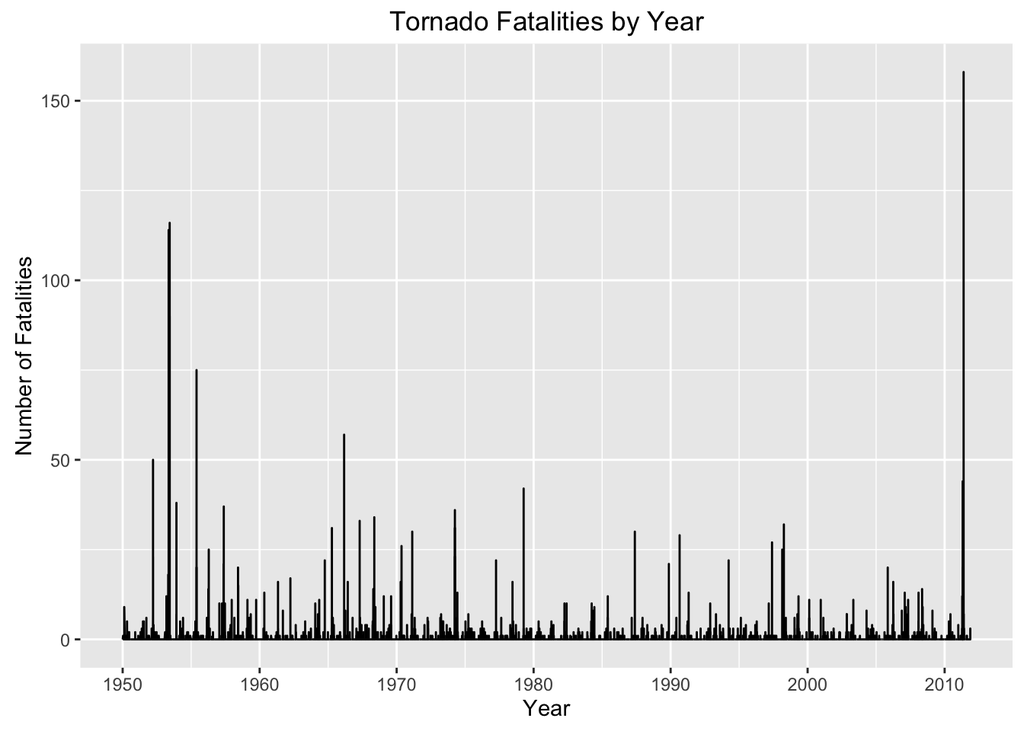

```r
ggplot(plot_data, aes(BGN_DATE, FATALITIES))+
        geom_line()+
        ggtitle("Tornado Fatalities by Year")+
        xlab("Year")+
        ylab("Number of Fatalities")
```

### Plot of tornado injuries by year

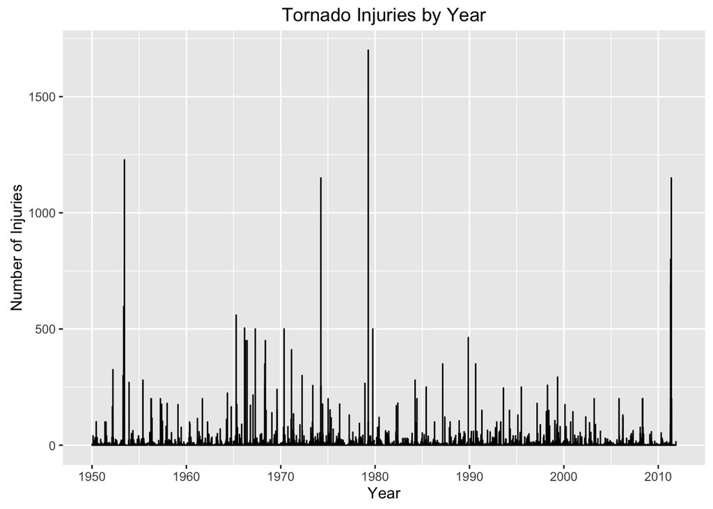

```r
ggplot(plot_data, aes(BGN_DATE, INJURIES))+
        geom_line()+
        ggtitle("Tornado Injuries by Year")+
        xlab("Year")+
        ylab("Number of Injuries")
```